# Econometric Empirical Exercise

group2

2017.4.4

# Probleam a.

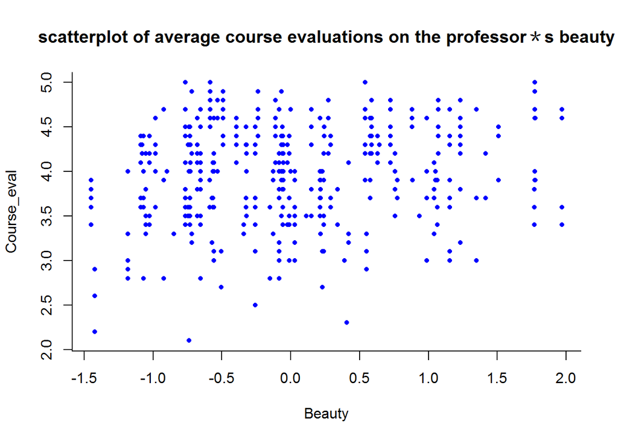

Answer for a: It seems that there is a weak positive relation between course evaluation and the beauty index.

# Problem b.

```
##
## Call:
## lm(formula = course_eval ~ beauty, data = df)
##
## Residuals:
##      Min       1Q   Median       3Q      Max
## -1.80015 -0.36304  0.07254  0.40207  1.10373
##
## Coefficients:
##             Estimate Std. Error t value Pr(>|t|)
## (Intercept)  3.99827    0.02535 157.727  < 2e-16 ***
## beauty       0.13300    0.03218   4.133 4.25e-05 ***
## ---
## Signif. codes:  0 '***' 0.001 '**' 0.01 '*' 0.05 '.' 0.1 ' ' 1
##
## Residual standard error: 0.5455 on 461 degrees of freedom
## Multiple R-squared:  0.03574,    Adjusted R-squared:  0.03364
## F-statistic: 17.08 on 1 and 461 DF,  p-value: 4.247e-05
```

```
##      beauty          course_eval
##  Min.   :-1.45049   Min.   :2.100
##  1st Qu.:-0.65627   1st Qu.:3.600
##  Median :-0.06801   Median :4.000
##  Mean   : 0.00000   Mean   :3.998
##  3rd Qu.: 0.54560   3rd Qu.:4.400
##  Max.   : 1.97002   Max.   :5.000
```

Anwser for b: Course_eval=3.998+0.133Beauty The estimated intercept is 3.998. The estimated slope is 0.133. Because the mean of beauty is near to zero.So due to the euqation,the estimated intercept is equal to the mean of Course_Eval.

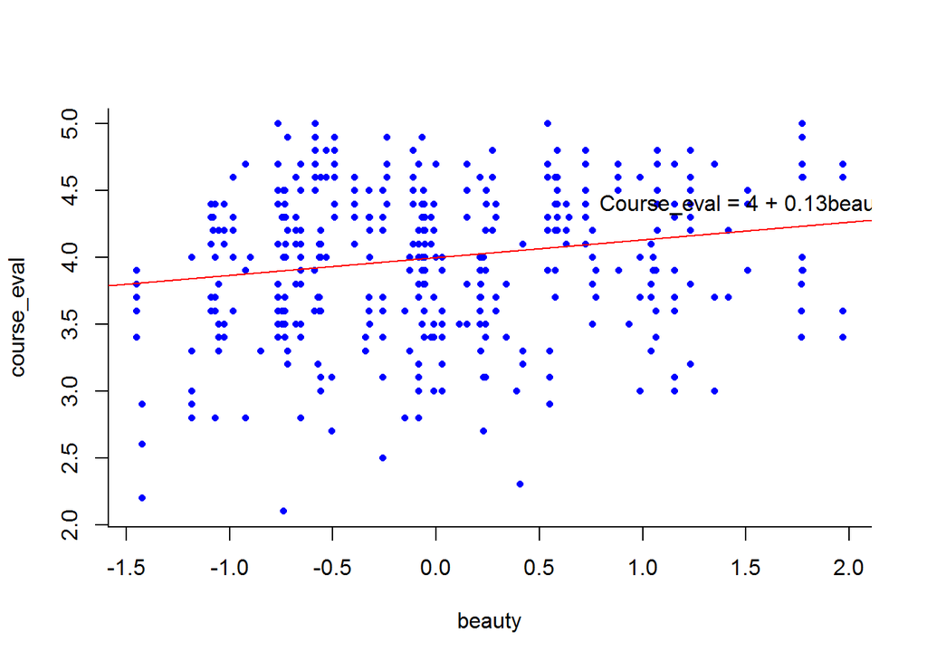

#Problem c.

```
##      beauty course_eval
##   0.7886477   0.5548656
```

Answer for c: The standard deviation of Beauty is 0.789. Thus, Professor Watson＊s predicted course evaluations = 4.00; Professor Stock＊s predicted course evaluations =4.00+0.133℅1℅0.789=4.105.

# Problem d:

Answer for d: The standard deviation of course evaluations is 0.55 and the standard deviation of beauty is 0.789. A one standard deviation increase in beauty is expected to increase course evaluation by 0.105. It’s much smaller than a standard deviation of course evaluations. Thus,the effect is small.

# Problem e:

Answer for e: No, R-squared is 0.03574,much less than 1, so that Beauty cannot explain the course evaluation efficiently.